# Game Test

Rob Carnell and Nancy McMillan

April 13, 2021

## Notation

- $X$ random variable representing the true distribution.
  - Univariate distribution
  - Distribution of bracket outcomes
- $P$ is the set of parameters for the true distribution.
  - parameters of a histogram over integers
  - matrix of parameters of a bracket where $p_{team, round}$ is the probability of a team reaching a particular round
- $Y$ random variable for the adversary distribution
  - Univariate distribution
  - Distribution of adversary bracket outcomes
- $n_A$ the number of adversaries
- $\theta$ set of parameters for the adversary distribution
  - parameters of a histogram over the integers
  - matrix of parameters of the adversary bracket
- $z$ test value or bracket
- $s(z|X=x)$ is the score of the test bracket against a bracket from the truth distribution
- $s(Y_k|X=x)$ is a random variable of scores with a distribution induced by the adversary distribution given a bracket from the truth distribution, where $k=1,\ldots,n_A$ adversaries
- $f$ is the distribution function of $X$

The goal is to maximize: $\int P(s(z|X=x) > s(Y_k|X=x) \forall k) f(x) dx$

## References

https://fantasy.espn.com/tournament-challenge-bracket/2021/en/whopickedwhom

https://projects.fivethirtyeight.com/2021-march-madness-predictions/

## Centered True and Crowd distributions with 5 adversaries

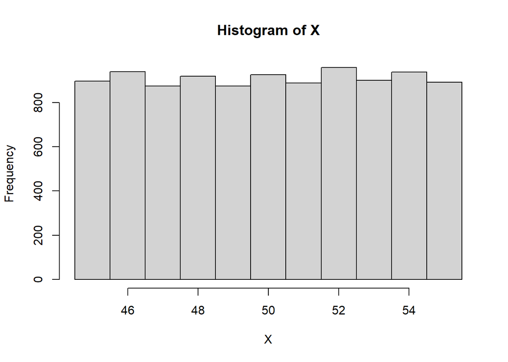

```r
Nsims <- 10000
Nplayers <- 5
# truth
X <- matrix(sample(45:55, size = Nsims, replace = TRUE), nrow = Nsims, ncol = 1)
hist(X, breaks = seq(44.5, 55.5, by = 1))
```

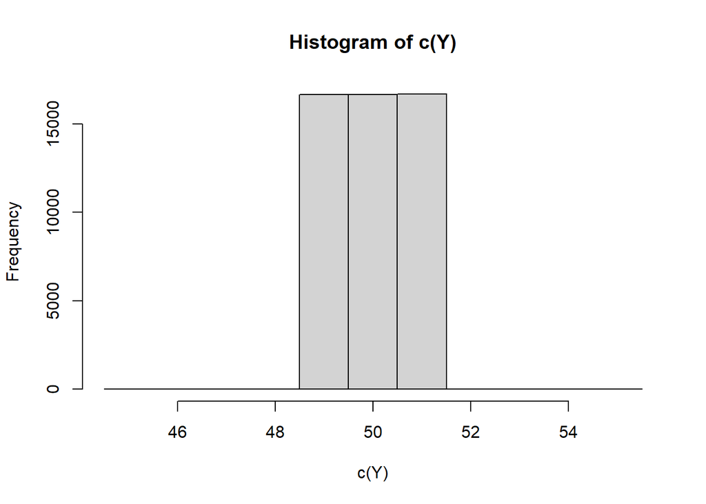

```r
# crowd
Y <- matrix(sample(49:51, size = Nplayers*Nsims, replace = TRUE), nrow = Nsims, ncol = Nplayers)
hist(c(Y), breaks = seq(44.5, 55.5, by = 1))
```

### Probability of Winning Alone

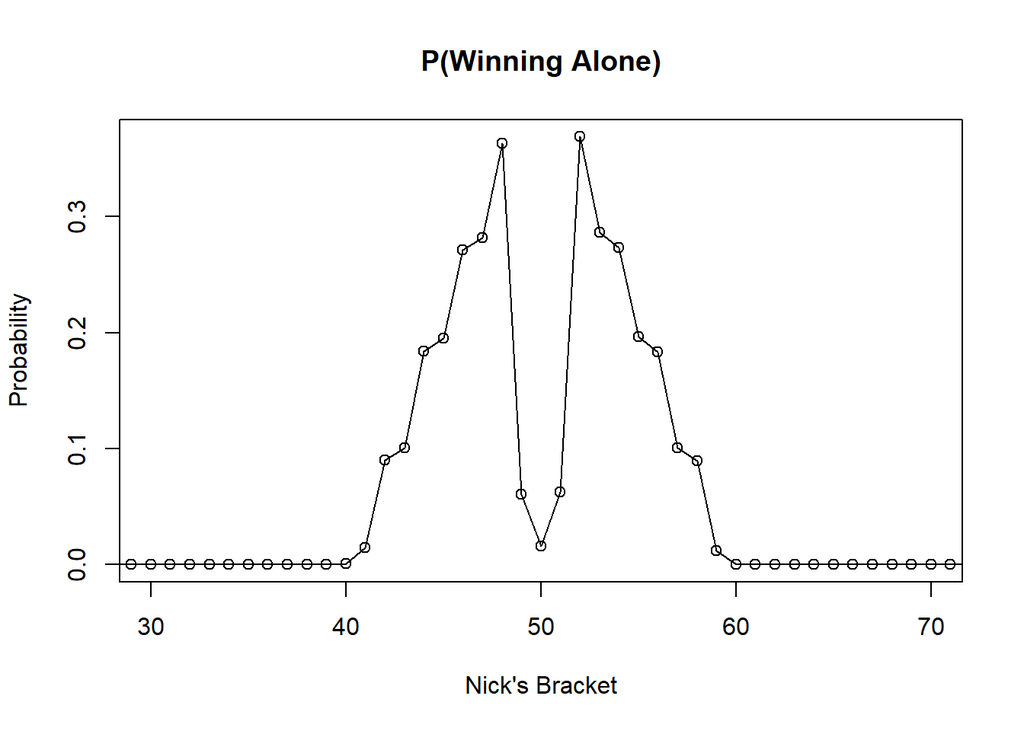

```r
f <- function(z)
{
  ind <- which(sapply(1:Nsims, function(i) all(abs(z - X[i]) < abs(Y[i,] - X[i]))))
  # % of the time winning
  return(length(ind) / Nsims)
}
temp1 <- sapply(1:100, f)
plot(1:100, temp1, type = "l", xlim = c(30, 70), main = "P(Winning Alone)",
     xlab = "Nick's Bracket", ylab = "Probability")
points(1:100, temp1)
```

### Probability of Winning

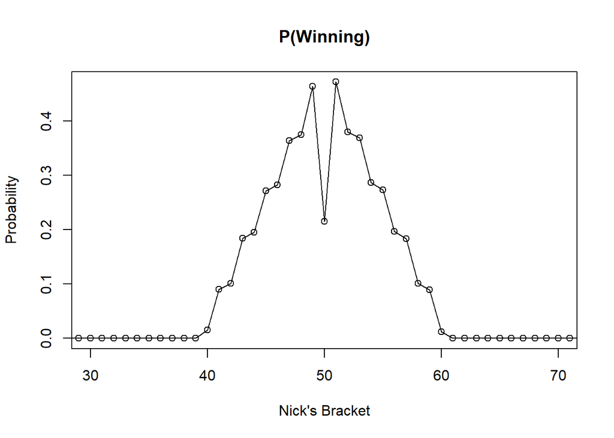

```r
f <- function(z)
{
  ind <- which(sapply(1:Nsims, function(i) all(abs(z - X[i]) <= abs(Y[i,] - X[i]))))
  # % of the time winning
  return(length(ind) / Nsims)
}
temp2 <- sapply(1:100, f)
plot(1:100, temp2, type = "l", xlim = c(30, 70), main = "P(Winning)",
     xlab = "Nick's Bracket", ylab = "Probability")
points(1:100, temp2)
```

### Expected Value of $1

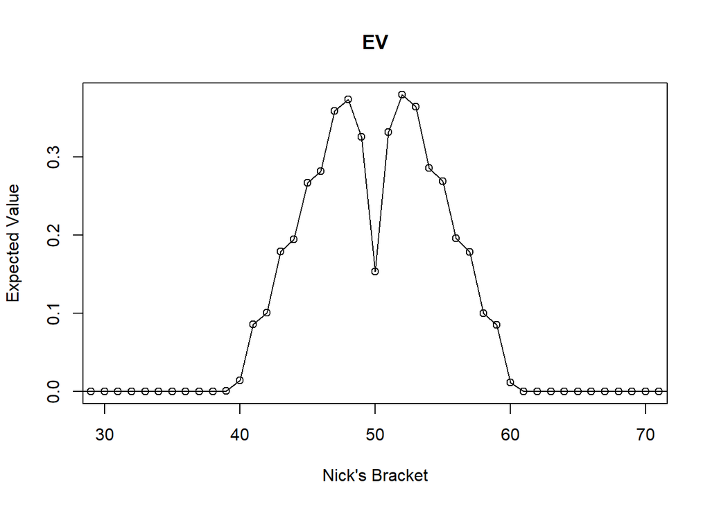

```r
f <- function(z)
{
  ind1 <- which(sapply(1:Nsims, function(i) all(abs(z - X[i]) < abs(Y[i,] - X[i]))))
  ind2 <- which(sapply(1:Nsims, function(i) all(abs(z - X[i]) <= abs(Y[i,] - X[i]))))
  ind3 <- sapply(1:Nsims, function(i) length(which(abs(z - X[i]) == abs(Y[i,] - X[i]))))
  p_alone <- length(ind1) / Nsims
  p_win <- length(ind2) / Nsims
  winners <- ifelse(ind3 == 0, 1, ind3)
  return(p_alone*1 + mean((p_win - p_alone)*1/winners))
}
temp3 <- sapply(1:100, f)
plot(1:100, temp3, type = "l", xlim = c(30, 70),
     main = "EV", xlab = "Nick's Bracket", ylab = "Expected Value")
points(1:100, temp3)
```

## Centered True and Crowd distributions with 15 adversaries

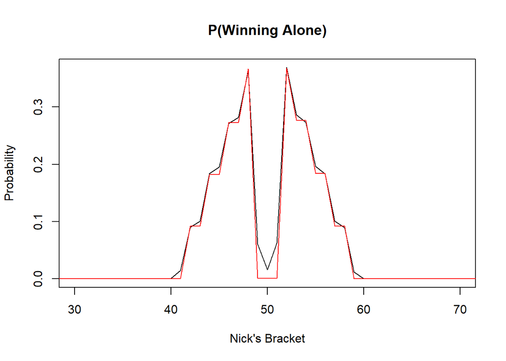

```r
Nplayers <- 15
# truth
X <- matrix(sample(45:55, size = Nsims, replace = TRUE), nrow = Nsims, ncol = 1)
#hist(X, breaks = seq(44.5, 55.5, by = 1))
# crowd
Y <- matrix(sample(49:51, size = Nplayers*Nsims, replace = TRUE), nrow = Nsims, ncol = Nplayers)
#hist(c(Y), breaks = seq(44.5, 55.5, by = 1))
################################################################################
# probability of winning alone
f <- function(z)
{
  ind <- which(sapply(1:Nsims, function(i) all(abs(z - X[i]) < abs(Y[i,] - X[i]))))
  # % of the time winning
  return(length(ind) / Nsims)
}
temp4 <- sapply(1:100, f)
plot(1:100, temp1, type = "l", xlim = c(30, 70), main = "P(Winning Alone)",
     xlab = "Nick's Bracket", ylab = "Probability")
lines(1:100, temp4, col = "red")
```

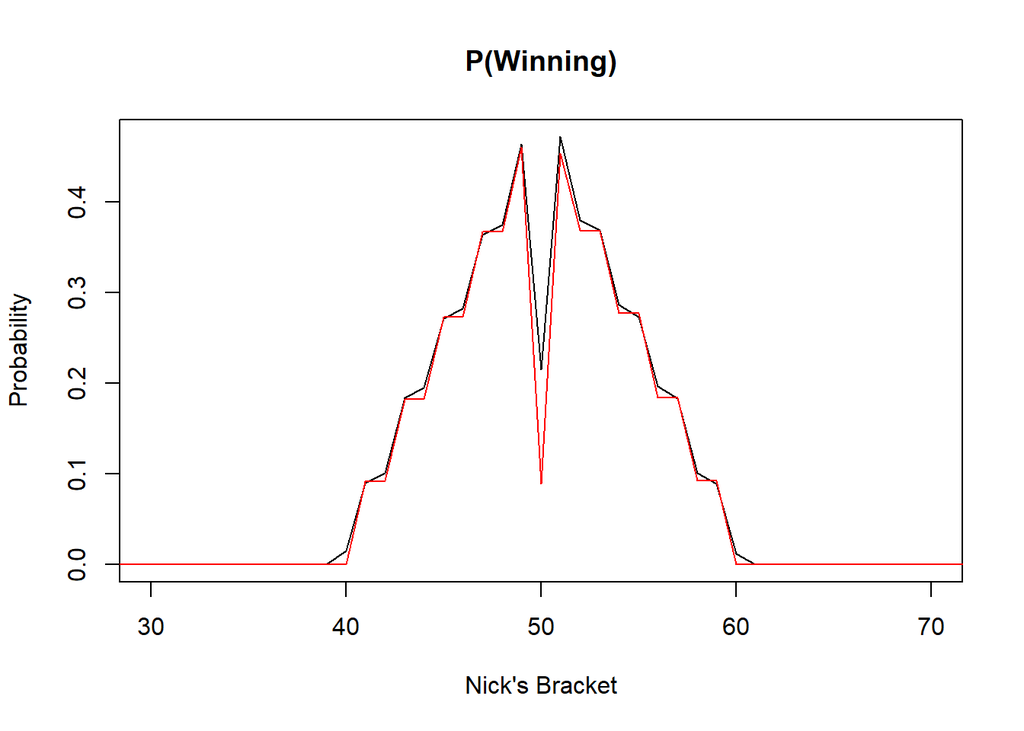

```r
################################################################################
# probability of winning
f <- function(z)
{
  ind <- which(sapply(1:Nsims, function(i) all(abs(z - X[i]) <= abs(Y[i,] - X[i]))))
  # % of the time winning
  return(length(ind) / Nsims)
}
temp5 <- sapply(1:100, f)
plot(1:100, temp2, type = "l", xlim = c(30, 70), main = "P(Winning)",
     xlab = "Nick's Bracket", ylab = "Probability")
lines(1:100, temp5, col = "red")
```

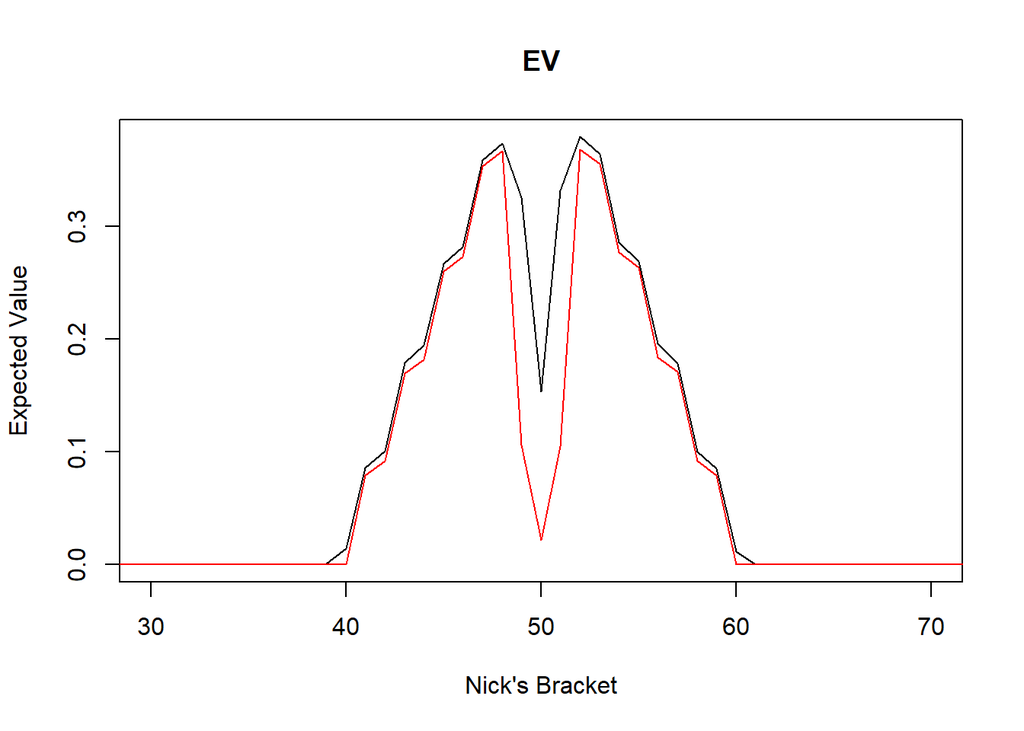

```r
################################################################################
# Expected Value of 1 dollar
f <- function(z)
{
  ind1 <- which(sapply(1:Nsims, function(i) all(abs(z - X[i]) < abs(Y[i,] - X[i]))))
  ind2 <- which(sapply(1:Nsims, function(i) all(abs(z - X[i]) <= abs(Y[i,] - X[i]))))
  ind3 <- sapply(1:Nsims, function(i) length(which(abs(z - X[i]) == abs(Y[i,] - X[i]))))
  p_alone <- length(ind1) / Nsims
  p_win <- length(ind2) / Nsims
  winners <- ifelse(ind3 == 0, 1, ind3)
  return(p_alone*1 + mean((p_win - p_alone)*1/winners))
}
temp6 <- sapply(1:100, f)
plot(1:100, temp3, type = "l", xlim = c(30, 70),
     main = "EV", xlab = "Nick's Bracket", ylab = "Expected Value")
lines(1:100, temp6, col = "red")
```

## Centered True and Non-centered Crowd distributions with 5 adversaries

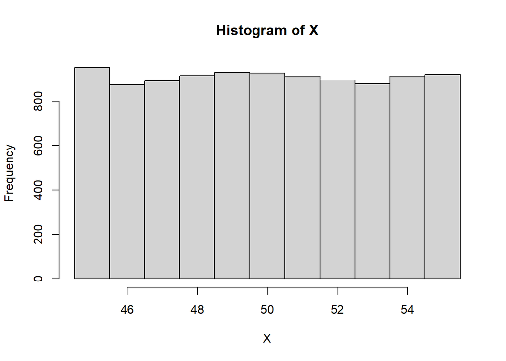

```r
Nsims <- 10000
Nplayers <- 5
# truth
X <- matrix(sample(45:55, size = Nsims, replace = TRUE), nrow = Nsims, ncol = 1)
hist(X, breaks = seq(44.5, 55.5, by = 1))
```

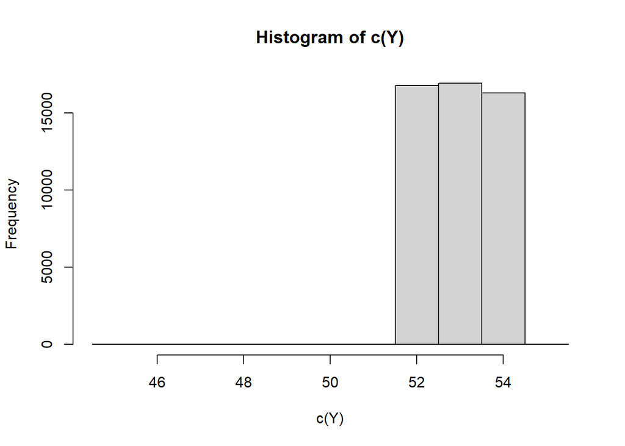

```r
# crowd
Y <- matrix(sample(52:54, size = Nplayers*Nsims, replace = TRUE), nrow = Nsims, ncol = Nplayers)
hist(c(Y), breaks = seq(44.5, 55.5, by = 1))
```

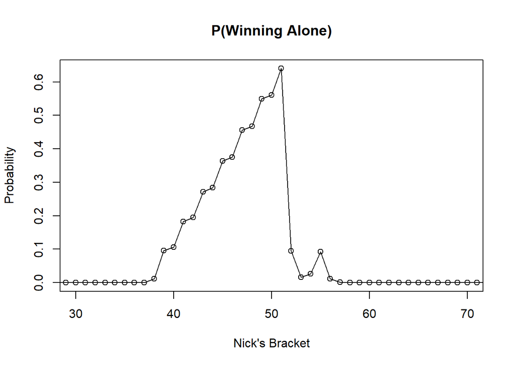

```r
################################################################################
# probability of winning alone
f <- function(z)
{
  ind <- which(sapply(1:Nsims, function(i) all(abs(z - X[i]) < abs(Y[i,] - X[i]))))
  # % of the time winning
  return(length(ind) / Nsims)
}
temp1 <- sapply(1:100, f)
plot(1:100, temp1, type = "l", xlim = c(30, 70), main = "P(Winning Alone)",
     xlab = "Nick's Bracket", ylab = "Probability")
points(1:100, temp1)
```

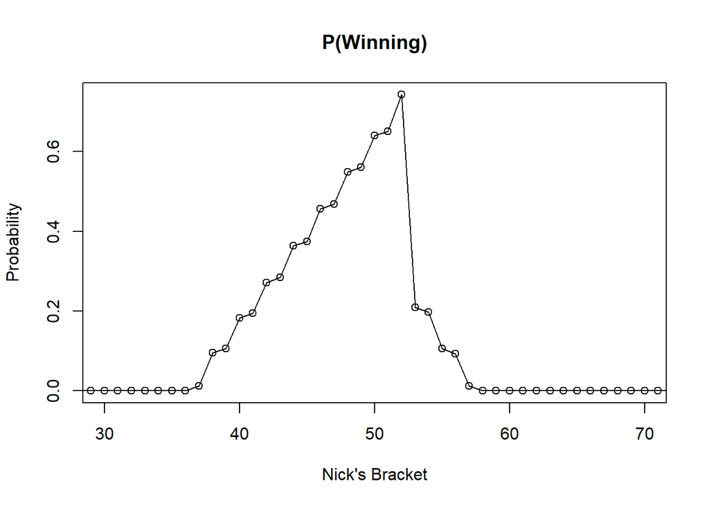

```r
################################################################################
# probability of winning
f <- function(z)
{
  ind <- which(sapply(1:Nsims, function(i) all(abs(z - X[i]) <= abs(Y[i,] - X[i]))))
  # % of the time winning
  return(length(ind) / Nsims)
}
temp2 <- sapply(1:100, f)
plot(1:100, temp2, type = "l", xlim = c(30, 70), main = "P(Winning)",
     xlab = "Nick's Bracket", ylab = "Probability")
points(1:100, temp2)
```

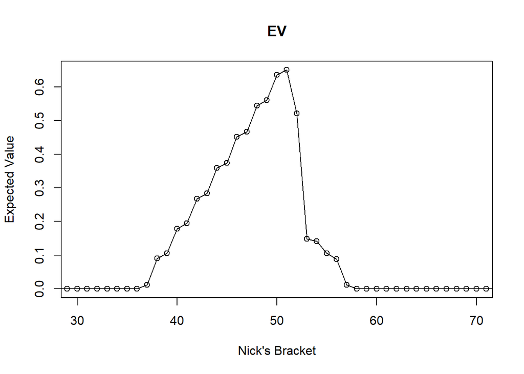

```r
################################################################################
# Expected Value of 1 dollar
f <- function(z)
{
  ind1 <- which(sapply(1:Nsims, function(i) all(abs(z - X[i]) < abs(Y[i,] - X[i]))))
  ind2 <- which(sapply(1:Nsims, function(i) all(abs(z - X[i]) <= abs(Y[i,] - X[i]))))
  ind3 <- sapply(1:Nsims, function(i) length(which(abs(z - X[i]) == abs(Y[i,] - X[i]))))
  p_alone <- length(ind1) / Nsims
  p_win <- length(ind2) / Nsims
  winners <- ifelse(ind3 == 0, 1, ind3)
  return(p_alone*1 + mean((p_win - p_alone)*1/winners))
}
temp3 <- sapply(1:100, f)
plot(1:100, temp3, type = "l", xlim = c(30, 70),
     main = "EV", xlab = "Nick's Bracket", ylab = "Expected Value")
points(1:100, temp3)
```

## Centered True and Non-centered Crowd distributions with 5 adversaries - Normal Distribution

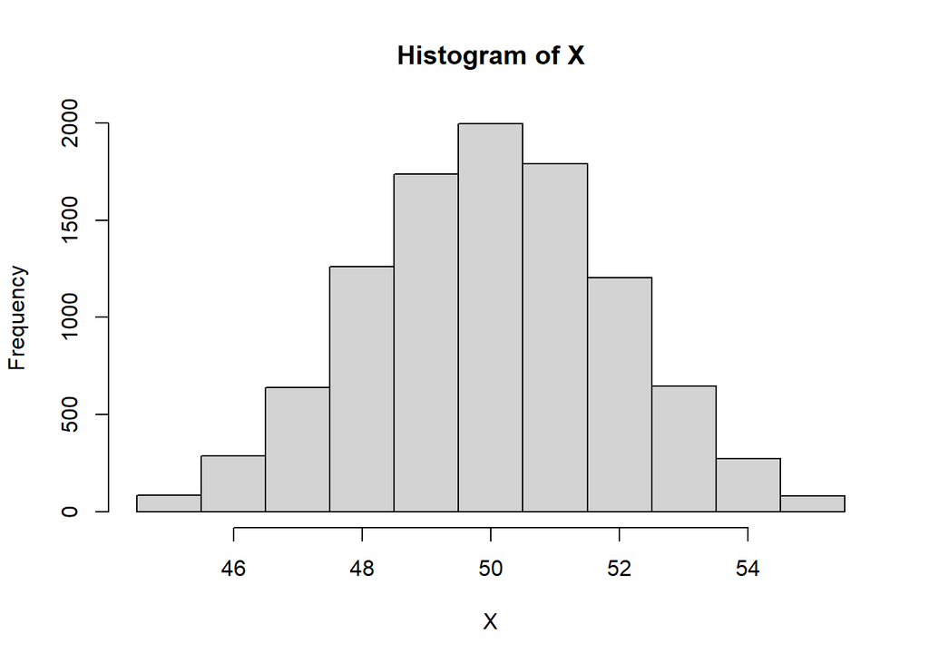

```r
Nsims <- 10000
Nplayers <- 5
# truth
X <- matrix(sample(45:55, size = Nsims, replace = TRUE, prob = dnorm(45:55, mean = 50, sd = 2)), nrow = Nsims, ncol = 1)
hist(X, breaks = seq(44.5, 55.5, by = 1))
```

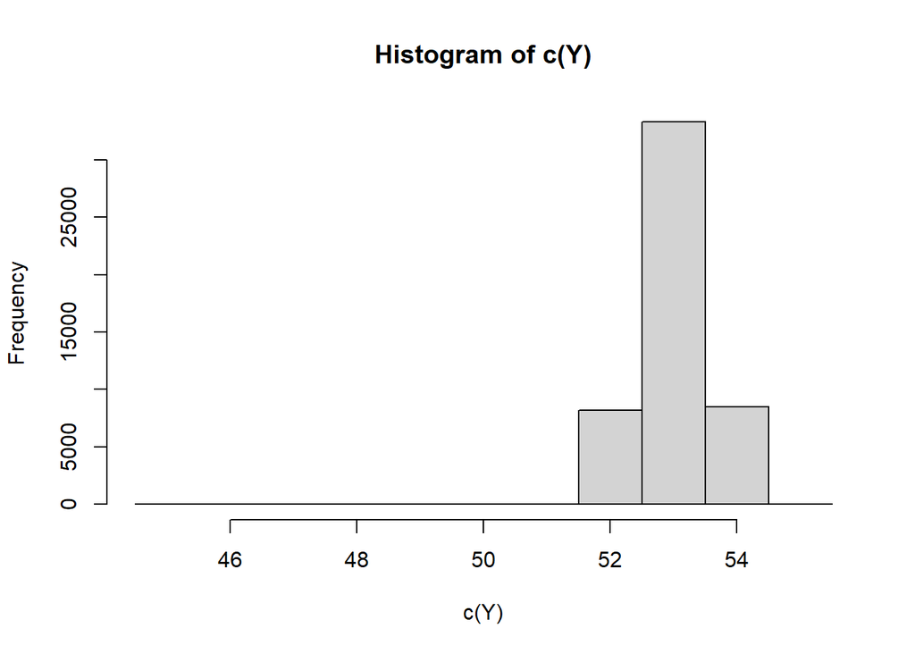

```r
# crowd
Y <- matrix(sample(52:54, size = Nplayers*Nsims, replace = TRUE, prob = dnorm(52:54, mean = 53, sd = 3/5)), nrow = Nsims, ncol = Nplayers)
hist(c(Y), breaks = seq(44.5, 55.5, by = 1))
```

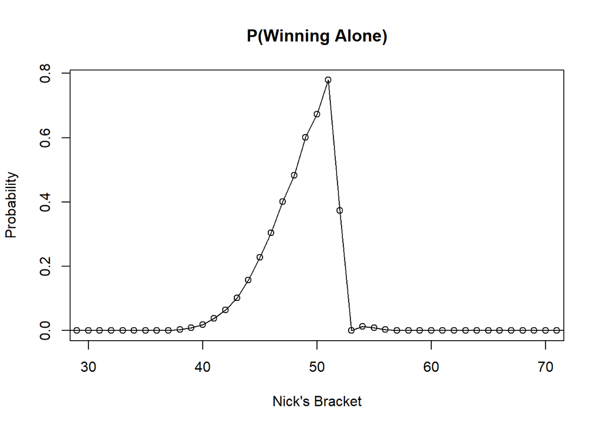

```r
################################################################################
# probability of winning alone
f <- function(z)
{
  ind <- which(sapply(1:Nsims, function(i) all(abs(z - X[i]) < abs(Y[i,] - X[i]))))
  # % of the time winning
  return(length(ind) / Nsims)
}
temp1 <- sapply(1:100, f)
plot(1:100, temp1, type = "l", xlim = c(30, 70), main = "P(Winning Alone)",
     xlab = "Nick's Bracket", ylab = "Probability")
points(1:100, temp1)
```

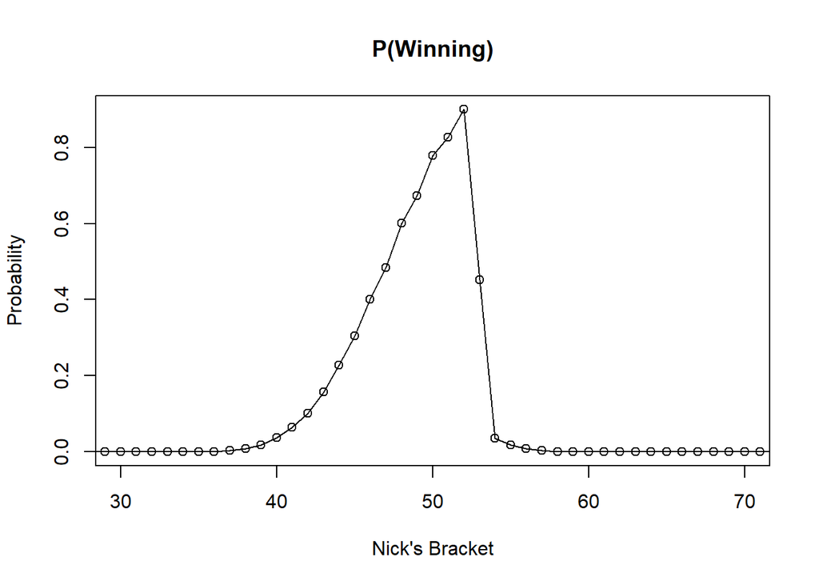

```r
################################################################################
# probability of winning
f <- function(z)
{
  ind <- which(sapply(1:Nsims, function(i) all(abs(z - X[i]) <= abs(Y[i,] - X[i]))))
  # % of the time winning
  return(length(ind) / Nsims)
}
temp2 <- sapply(1:100, f)
plot(1:100, temp2, type = "l", xlim = c(30, 70), main = "P(Winning)",
     xlab = "Nick's Bracket", ylab = "Probability")
points(1:100, temp2)
```

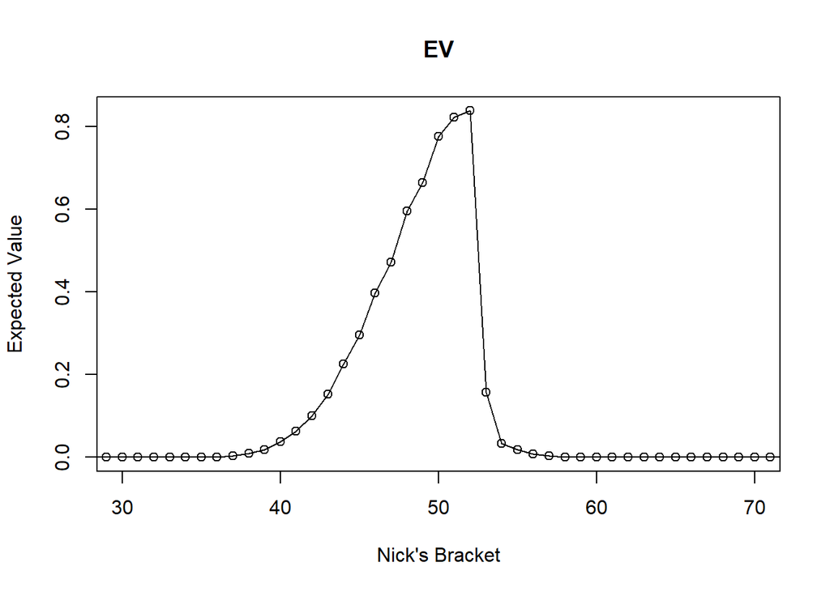

```r
################################################################################
# Expected Value of 1 dollar
f <- function(z)
{
  ind1 <- which(sapply(1:Nsims, function(i) all(abs(z - X[i]) < abs(Y[i,] - X[i]))))
  ind2 <- which(sapply(1:Nsims, function(i) all(abs(z - X[i]) <= abs(Y[i,] - X[i]))))
  ind3 <- sapply(1:Nsims, function(i) length(which(abs(z - X[i]) == abs(Y[i,] - X[i]))))
  p_alone <- length(ind1) / Nsims
  p_win <- length(ind2) / Nsims
  winners <- ifelse(ind3 == 0, 1, ind3)
  return(p_alone*1 + mean((p_win - p_alone)*1/winners))
}
temp3 <- sapply(1:100, f)
plot(1:100, temp3, type = "l", xlim = c(30, 70),
     main = "EV", xlab = "Nick's Bracket", ylab = "Expected Value")
points(1:100, temp3)
```

## Theoretical Estimates

Let $X$ be a continuous random variable with CDF $F_X(x)$ and PDF $f_X(x)$ be the true distribution of results. Let $Y_k$ be a continuous random variable with CDF $F_Y(y)$ and PDF $f_Y(y)$ be the distribution of adversary results with $k \in [1,n]$

$$g(z) = \int P(s(z|X=x) > s(Y_k|X=x)\ \ \forall k) f(x) dx$$

Let the score function be the distance between the player guess and the true score versus the smallest distance between the adversary distributions and the true score

$$= \int_x P((z-X)^2 < (Y_k-X)^2\ \ \forall k\ \ | X=x) f(x) dx$$

Goal is to maximize $g(z)$

Let, $W = u(Y) = (Y - x)^2$

$$F_W(w) = P(W \leq w) = P((Y-x)^2 \leq w) = P(-\sqrt{w} \leq Y-x \leq \sqrt{w})$$

$$= P(-\sqrt{w}+x \leq Y \leq \sqrt{w}+x) = F_Y(\sqrt{w}+x) - F_Y(-\sqrt{w}+x)$$

$$f_W(w) = \frac{d}{dw}F_W(w) = f_Y(\sqrt{w}+x)\frac{1}{2\sqrt{w}} + f_Y(-\sqrt{w}+x)\frac{1}{2\sqrt{w}}$$
Let $F^{(n)}_W(w)$ be the cummulative distribution function of the n^{th} order statistic of $W$

$$F^{(1)}_W(w) = 1 - (1 - F_W(w))^n$$

$$f^{(1)}_W(w) = n (1-F_W(w))^{n-1} f_W(w)$$

$$g(z) = \int_x P((z-X)^2 < (Y_k-X)^2\ \ \forall k\ \ | X=x) f(x) dx$$

$$= \int_x P(W^{(1)} > (z-X)^2 \ | \ X=x) f(x) dx = \int_x [1-F_W((z-x)^2)]f(x)dx$$

$$= \int_x [1 - F_Y(\sqrt{(z-x)^2}+x) + F_Y(-\sqrt{(z-x)^2}+x)] \ f(x)dx$$

$$= \int_x [1 - F_Y(z) + F_Y(2x-z)] \ f(x)dx$$

### Normal distribution example

$$X \sim N(\mu_x, \sigma_x)$$

$$Y \sim N(\mu_y, \sigma_y)$$

$$g(z) = \int_x [1 - F_Y(z) + F_Y(2x-z)] \ f(x)dx$$

Maximize $g(x)$ with respect to z:

$$g'(z) = \frac{d}{dz} \int_x [1 - F_Y(z) + F_Y(2x-z)] \ f(x)dx = 0$$

$$= \int_x [-f_Y(z) + f_Y(2x-z)(-1)] f(x)dx$$

$$\int_x [f_Y(z) + f_Y(2x-z)] f(x)dx = 0$$

$$f_Y(z) + \int_x f_Y(2x-z) f(x)dx = 0$$

$$\int_x \left[ \frac{1}{\sqrt{2\pi}\sigma_y}e^{\frac{(z-\mu_y)^2}{2\sigma_y^2}} + \frac{1}{\sqrt{2\pi}\sigma_y}e^{\frac{(2x-z-\mu_y)^2}{2\sigma_y^2}} \right] \frac{1}{\sqrt{2\pi}\sigma_x} e^{\frac{(x-\mu_x)^2}{2\sigma_x}} dx$$

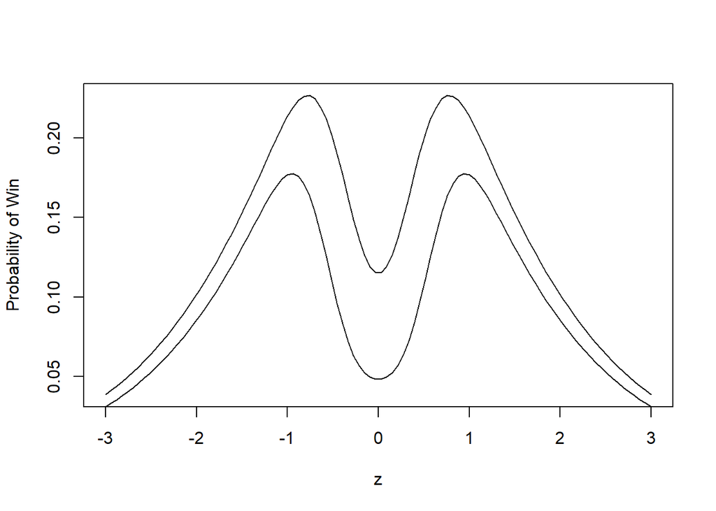

```r
fx <- function(x, mu_x, sigma_x) dnorm(x, mu_x, sigma_x)

#integrate(fx, lower = -Inf, upper = Inf, mu_x = 3, sigma_x = 1)

fy <- function(y, mu_y, sigma_y) dnorm(y, mu_y, sigma_y)

#integrate(fy, lower = -Inf, upper = Inf, mu_y = 3, sigma_y = 1)

Fy <- function(y, mu_y, sigma_y) pnorm(y, mu_y, sigma_y)

#Fy(0, 0, 1)

Fx <- function(x, mu_x, sigma_x) pnorm(x, mu_x, sigma_x)

#Fx(0, 0, 1)

fw <- function(w, x, mu_y, sigma_y) fy(sqrt(w)+x, mu_y, sigma_y)/2/sqrt(w) + fy(x-sqrt(w), mu_y, sigma_y)/2/sqrt(w)

#integrate(fw, lower = 0, upper = Inf, mu_y = 3, sigma_y = 1, x = 2)

Fw <- function(w, x, mu_y, sigma_y) Fy(sqrt(w)+x, mu_y, sigma_y) - Fy(x-sqrt(w), mu_y, sigma_y)

#Fw(9, -3, 0, 1)

fwn <- function(w, x, mu_y, sigma_y, n) n * (1-Fw(w, x, mu_y, sigma_y))^(n-1) * fw(w, x, mu_y, sigma_y)

#integrate(fwn, lower = 0, upper = Inf, mu_y = 3, sigma_y = 1, x = 2, n = 5)

Fwn <- function(w, x, mu_y, sigma_y, n) 1 - (1 - Fw(w, x, mu_y, sigma_y))^n

#Fwn(9, -3, 0, 1, 5)

pzx <- function(z, x, mu_y, sigma_y, mu_x, sigma_x, n)
{
  1 - Fwn((z-x)^2, x, mu_y, sigma_y, n)
}

pzx_fx <- function(x, z, mu_x, sigma_x, mu_y, sigma_y, n)
{
  pzx(z, x, mu_y, sigma_y, mu_x, sigma_x, n) * fx(x, mu_x, sigma_x)
}

fz <- function(z, mu_x, sigma_x, mu_y, sigma_y, n)
{
  integrate(pzx_fx, lower = -Inf, upper = Inf, z = z, mu_x = mu_x, sigma_x = sigma_x, mu_y = mu_y, sigma_y = sigma_y, n = n)
}

fzz <- sapply(seq(-3, 3, length = 100), function(z) fz(z, 0, 1, 0, 0.5, 5)$value)
plot(seq(-3, 3, length = 100), fzz, type = "l", xlab = "z", ylab = "Probability of Win")

fzz10 <- sapply(seq(-3, 3, length = 100), function(z) fz(z, 0, 1, 0, 0.5, 10)$value)
plot(seq(-3, 3, length = 100), fzz, type = "l", xlab = "z", ylab = "Probability of Win")
lines(seq(-3, 3, length = 100), fzz10)
```

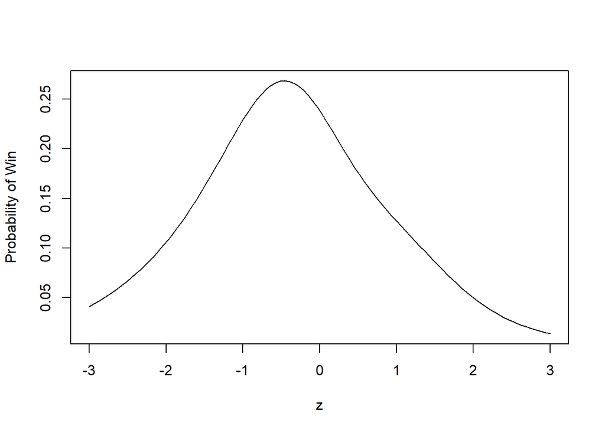

```r
fzz <- sapply(seq(-3, 3, length = 100), function(z) fz(z, 0, 1, 0.5, 1, 5)$value)
plot(seq(-3, 3, length = 100), fzz, type = "l", xlab = "z", ylab = "Probability of Win")
```

### Uniform density example

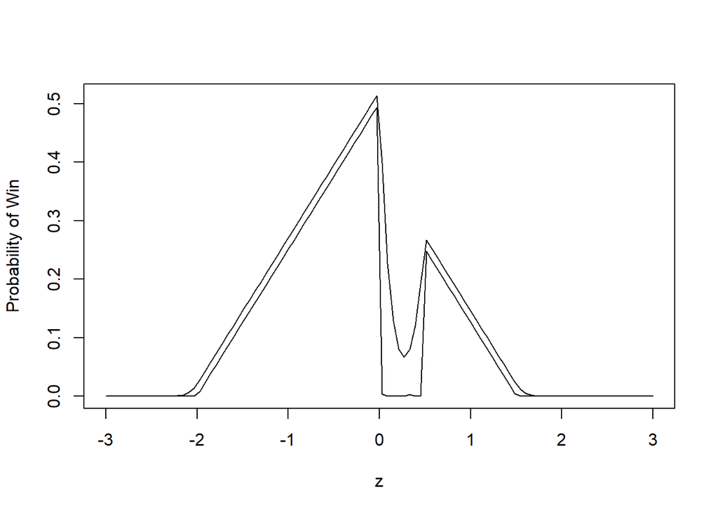

```r
fx <- function(x, a_x, b_x) dunif(x, a_x, b_x)

#integrate(fx, lower = -Inf, upper = Inf, a_x = -1, b_x = 1)

fy <- function(y, a_y, b_y) dunif(y, a_y, b_y)

#integrate(fy, lower = -Inf, upper = Inf, a_y = 1, b_y = 3)

Fy <- function(y, a_y, b_y) punif(y, a_y, b_y)

#Fy(0, -1, 1)

Fx <- function(x, a_x, b_x) punif(x, a_x, b_x)

#Fx(2, 1, 3)

fw <- function(w, x, a_y, b_y) fy(sqrt(w)+x, a_y, b_y)/2/sqrt(w) + fy(x-sqrt(w), a_y, b_y)/2/sqrt(w)

#integrate(fw, lower = 0, upper = Inf, a_y = 1, b_y = 3, x = 5)

Fw <- function(w, x, a_y, b_y) Fy(sqrt(w)+x, a_y, b_y) - Fy(x-sqrt(w), a_y, b_y)

#Fw(0.5, 0.4, -1, 1)

fwn <- function(w, x, a_y, b_y, n) n * (1-Fw(w, x, a_y, b_y))^(n-1) * fw(w, x, a_y, b_y)

#integrate(fwn, lower = 0, upper = Inf, a_y = 1, b_y = 3, x = 2, n = 5)

Fwn <- function(w, x, a_y, b_y, n) 1 - (1 - Fw(w, x, a_y, b_y))^n

#Fwn(0.5, 0.4, 0, 2, 5)

pzx <- function(z, x, a_y, b_y, a_x, b_x, n)
{
  1 - Fwn((z-x)^2, x, a_y, b_y, n)
}

pzx_fx <- function(x, z, a_x, b_x, a_y, b_y, n)
{
  pzx(z, x, a_y, b_y, a_x, b_x, n) * fx(x, a_x, b_x)
}

fz <- function(z, a_x, b_x, a_y, b_y, n)
{
  integrate(pzx_fx, lower = -Inf, upper = Inf, z = z, a_x = a_x, b_x = b_x, a_y = a_y, b_y = b_y, n = n)
}

fzz <- sapply(seq(-3, 3, length = 100), function(z) fz(z, -1, 1, 0, 0.5, 5)$value)
plot(seq(-3, 3, length = 100), fzz, type = "l", xlab = "z", ylab = "Probability of Win")

fzz10 <- sapply(seq(-3, 3, length = 100), function(z) fz(z, -1, 1, 0, 0.5, 100)$value)
plot(seq(-3, 3, length = 100), fzz, type = "l", xlab = "z", ylab = "Probability of Win")
lines(seq(-3, 3, length = 100), fzz10)
```

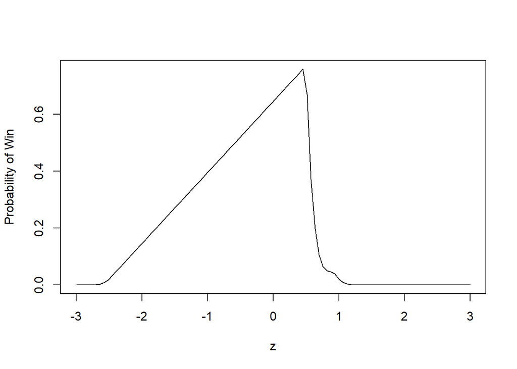

```r
fzz <- sapply(seq(-3, 3, length = 100), function(z) fz(z, -1, 1, 0.5, 1, 5)$value)
plot(seq(-3, 3, length = 100), fzz, type = "l", xlab = "z", ylab = "Probability of Win")
```